# Análisis Predictivo en Business Intelligence: clasificación en R

- Mostrar todo el código
- Ocultar todo el código
- Ver el código fuente

Autor/a

Fernando Salcedo Mejía Eco, Ms

Fecha de publicación

1 de febrero de 2026

Este notebook desarrolla en R los casos de estudio de la presentación **Análisis Predictivo en Business Intelligence**. En este notebook usamos tres de sus paquetes:

| Paquete | Funciones | Para qué sirve |
| --- | --- | --- |
| `parsnip` | `logistic_reg()`, `decision_tree()`, `rand_forest()`, `boost_tree()`, `fit()` | Especificar y estimar los modelos |
| `broom` | `tidy()`, `augment()` | Ver los coeficientes y agregar las predicciones a los datos |
| `yardstick` | `metric_set()`, `conf_mat()`, `roc_curve()` | Evaluar las predicciones |

**Código**

```r
library(tidymodels)
library(tidyverse)
library(rpart.plot)

theme_set(theme_minimal(base_size = 13))
options(digits = 3) # mostrar los resultados con 3 decimales
```

# 1 Fuga de clientes (churn)

Una empresa de telecomunicaciones quiere decidir **a qué clientes dirigir una campaña de retención**. Se comparan cuatro modelos de clasificación: logit, árbol de clasificación, random forest y XGBoost.

## 1.1 Datos

Los datos disponibles describen a 5.000 clientes de la empresa. Cada fila es un cliente y las columnas son:

| Variable | Tipo | Descripción | Valores |
| --- | --- | --- | --- |
| `id_cliente` | Identificador | Número único del cliente | 1 a 5.000 |
| `antiguedad` | Numérica | Meses que lleva el cliente con la empresa | 1 a 72 meses |
| `cargo_mensual` | Numérica | Valor que paga el cliente cada mes (USD) | 20 a 150 USD |
| `contrato` | Categórica | Tipo de contrato | Mensual, Anual, Bianual |
| `llamadas_soporte` | Numérica (conteo) | Número de llamadas del cliente al servicio de soporte | 0, 1, 2, … |
| `pago_electronico` | Binaria | Si el cliente paga con medio electrónico | 1 = sí, 0 = no |
| `churn` | Binaria (**respuesta**) | Si el cliente abandonó la empresa | 1 = Fuga, 0 = Permanece |
| `conjunto` | Identificador | Partición asignada al cliente | entrenamiento, prueba |

`churn` es la variable que se quiere predecir; las cinco variables de antigüedad, cargo, contrato, llamadas y forma de pago son los **predictores**. Al leer los datos, `contrato` y `churn` se convierten en factores: `Mensual` queda como categoría de referencia y `Fuga` como la clase de interés.

**Código**

```r
telco <- read_csv("datos/telco_churn.csv", show_col_types = FALSE)

telco <- telco |>
  mutate(
    contrato = factor(contrato, levels = c("Mensual", "Anual", "Bianual")),
    churn = factor(churn, levels = c(0, 1), labels = c("Permanece", "Fuga"))
  )

head(telco)
```

| id_cliente | antiguedad | cargo_mensual | contrato | llamadas_soporte | pago_electronico | churn | conjunto |
| --- | --- | --- | --- | --- | --- | --- | --- |
| 1 | 38 | 52.2 | Bianual | 1 | 0 | Permanece | entrenamiento |
| 2 | 45 | 119.3 | Anual | 2 | 0 | Permanece | entrenamiento |
| 3 | 36 | 98.6 | Mensual | 1 | 1 | Fuga | entrenamiento |
| 4 | 48 | 59.7 | Bianual | 3 | 0 | Permanece | entrenamiento |
| 5 | 5 | 50.0 | Anual | 3 | 0 | Permanece | entrenamiento |
| 6 | 31 | 88.0 | Anual | 0 | 0 | Permanece | entrenamiento |

## 1.2 Análisis exploratorio

**Código**

```r
tasa_general <- mean(telco$churn == "Fuga")
```

La tasa de fuga general es de 20.8 %: aproximadamente uno de cada cinco clientes abandona la empresa. El análisis exploratorio busca qué diferencia a los clientes que se van de los que permanecen.

### 1.2.1 Variables numéricas

Se compara la distribución de la antigüedad y del cargo mensual entre los clientes que se van y los que permanecen:

**Código**

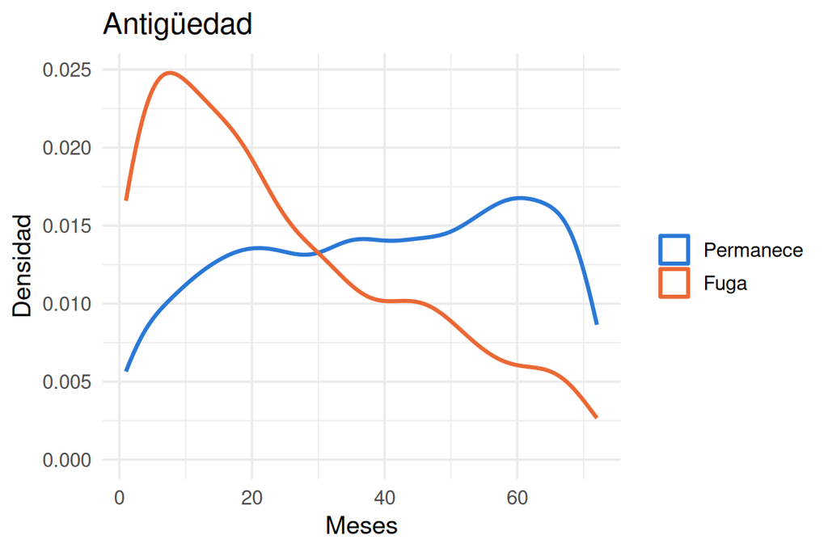

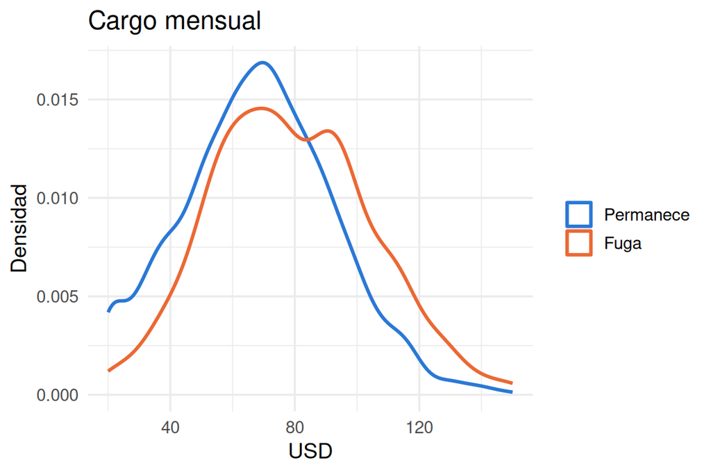

```r
colores_churn <- c(Permanece = "#2a78d6", Fuga = "#eb6834")

ggplot(telco, aes(antiguedad, color = churn)) +
  geom_density(linewidth = 1) +
  scale_color_manual(values = colores_churn) +
  labs(title = "Antigüedad", x = "Meses", y = "Densidad", color = NULL)
ggplot(telco, aes(cargo_mensual, color = churn)) +
  geom_density(linewidth = 1) +
  scale_color_manual(values = colores_churn) +
  labs(title = "Cargo mensual", x = "USD", y = "Densidad", color = NULL)
```

Los clientes que se fugan se concentran en los **primeros meses** de relación con la empresa, mientras que los que permanecen tienen antigüedades mayores. En el cargo mensual la diferencia es menor, pero los clientes que se van tienden a pagar **cargos más altos**.

### 1.2.2 Variables categóricas

Para las variables con pocas categorías se calcula la tasa de fuga de cada categoría. La línea punteada es la tasa de fuga general. Las llamadas a soporte se agrupan en “4 o más” porque hay pocos clientes con más llamadas.

**Código**

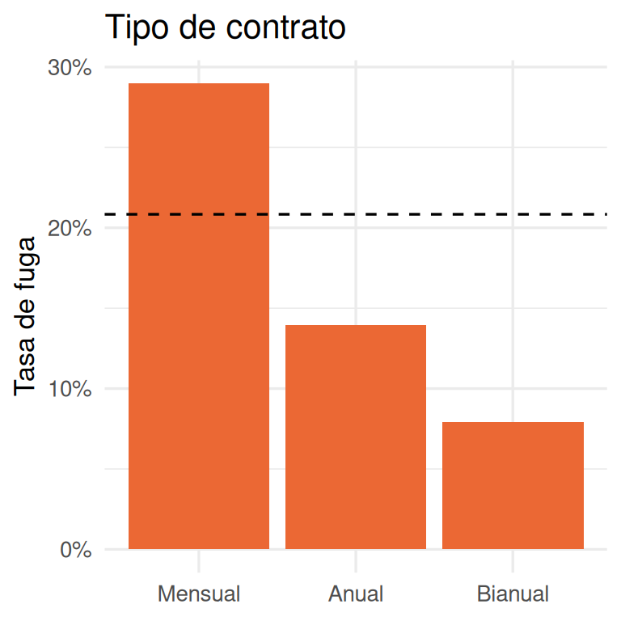

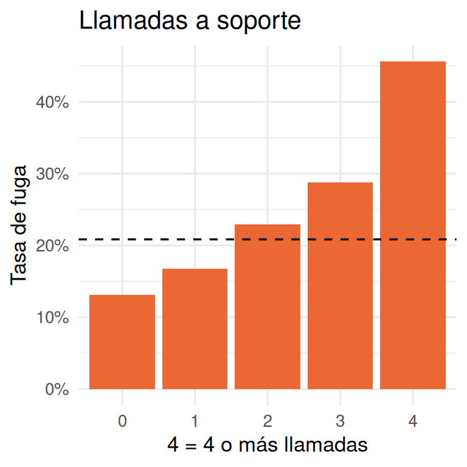

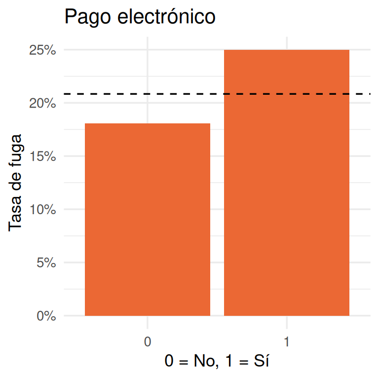

```r
telco |>
  group_by(contrato) |>
  summarise(tasa_fuga = mean(churn == "Fuga")) |>
  ggplot(aes(contrato, tasa_fuga)) +
  geom_col(fill = "#eb6834") +
  geom_hline(yintercept = tasa_general, linetype = "dashed") +
  scale_y_continuous(labels = scales::percent) +
  labs(title = "Tipo de contrato", x = NULL, y = "Tasa de fuga")
telco |>
  mutate(llamadas = pmin(llamadas_soporte, 4)) |>
  group_by(llamadas) |>
  summarise(tasa_fuga = mean(churn == "Fuga")) |>
  ggplot(aes(factor(llamadas), tasa_fuga)) +
  geom_col(fill = "#eb6834") +
  geom_hline(yintercept = tasa_general, linetype = "dashed") +
  scale_y_continuous(labels = scales::percent) +
  labs(
    title = "Llamadas a soporte",
    x = "4 = 4 o más llamadas",
    y = "Tasa de fuga"
  )
telco |>
  group_by(pago_electronico) |>
  summarise(tasa_fuga = mean(churn == "Fuga")) |>
  ggplot(aes(factor(pago_electronico), tasa_fuga)) +
  geom_col(fill = "#eb6834") +
  geom_hline(yintercept = tasa_general, linetype = "dashed") +
  scale_y_continuous(labels = scales::percent) +
  labs(title = "Pago electrónico", x = "0 = No, 1 = Sí", y = "Tasa de fuga")
```

- **Contrato:** los clientes con contrato mensual se van mucho más que los de contratos largos; el contrato bianual tiene la tasa de fuga más baja.
- **Llamadas a soporte:** la tasa de fuga crece con cada llamada adicional. Un cliente que llama mucho a soporte es un cliente insatisfecho.
- **Pago electrónico:** los clientes que pagan con medio electrónico se fugan algo más que los demás.

### 1.2.3 Interacción entre antigüedad y cargo mensual

Las variables también pueden actuar en conjunto. El mapa de calor muestra la tasa de fuga para cada combinación de tramos de antigüedad y de cargo mensual. Un tramo como `(0,12]` significa “más de 0 y hasta 12”.

**Código**

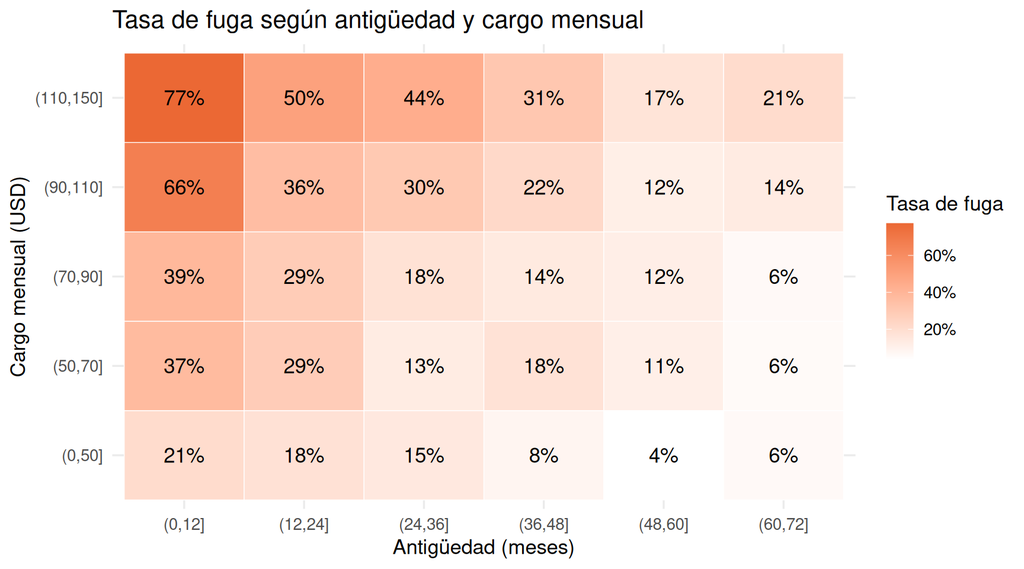

```r
telco |>
  mutate(
    tramo_antiguedad = cut(antiguedad, breaks = c(0, 12, 24, 36, 48, 60, 72)),
    tramo_cargo = cut(cargo_mensual, breaks = c(0, 50, 70, 90, 110, 150))
  ) |>
  group_by(tramo_antiguedad, tramo_cargo) |>
  summarise(tasa_fuga = mean(churn == "Fuga")) |>
  ggplot(aes(tramo_antiguedad, tramo_cargo, fill = tasa_fuga)) +
  geom_tile(color = "white") +
  geom_text(aes(label = scales::percent(tasa_fuga, accuracy = 1))) +
  scale_fill_gradient(
    low = "white",
    high = "#eb6834",
    labels = scales::percent
  ) +
  labs(
    title = "Tasa de fuga según antigüedad y cargo mensual",
    x = "Antigüedad (meses)",
    y = "Cargo mensual (USD)",
    fill = "Tasa de fuga"
  )
```

La fuga es máxima en la esquina superior izquierda: **clientes nuevos (menos de un año) con cargos altos (más de 90 USD)**, donde se van dos de cada tres clientes o más. Este tipo de combinación es difícil de capturar con un logit que solo incluye cada variable por separado, pero los árboles, el random forest y XGBoost la pueden detectar por sí mismos.

## 1.3 Entrenamiento y prueba

Los datos se dividen con `initial_split()` del paquete `rsample`: 70 % de los clientes para entrenar y 30 % para evaluar. Con `strata = churn` la partición es **estratificada**, es decir, ambos conjuntos conservan la misma proporción de clientes que se fugan. `set.seed()` fija la semilla aleatoria para que la partición sea siempre la misma.

Antes de partir se eliminan las columnas `id_cliente` y `conjunto` porque no son predictores. Así, la fórmula `churn ~ .` significa “predecir `churn` con todas las demás columnas”.

**Nota**

Esta partición es distinta a la de la columna `conjunto`, que usan los notebooks de Python y de paquetes individuales. Por eso los resultados de este notebook no coinciden exactamente con los de esos notebooks.

**Código**

```r
set.seed(2026)
datos <- telco |>
  select(-id_cliente, -conjunto)

particion <- initial_split(datos, prop = 0.7, strata = churn)
entrenamiento <- training(particion)
prueba <- testing(particion)

tibble(
  conjunto = c("Entrenamiento", "Prueba"),
  clientes = c(nrow(entrenamiento), nrow(prueba)),
  tasa_fuga = c(
    mean(entrenamiento$churn == "Fuga"),
    mean(prueba$churn == "Fuga")
  )
)
```

| conjunto | clientes | tasa_fuga |
| --- | --- | --- |
| Entrenamiento | 3499 | 0.208 |
| Prueba | 1501 | 0.209 |

## 1.4 Regresión logística (logit)

En tidymodels cada modelo se estima en dos pasos: primero se **especifica** el tipo de modelo y luego se **estima** con `fit()`, indicando la fórmula y los datos.

**Código**

```r
logit_fit <- logistic_reg() |>
  fit(churn ~ ., data = entrenamiento)

tidy(logit_fit)
```

| term | estimate | std.error | statistic | p.value |
| --- | --- | --- | --- | --- |
| (Intercept) | -2.065 | 0.186 | -11.11 | 0 |
| antiguedad | -0.040 | 0.002 | -16.00 | 0 |
| cargo_mensual | 0.022 | 0.002 | 11.05 | 0 |
| contratoAnual | -1.188 | 0.120 | -9.87 | 0 |
| contratoBianual | -1.812 | 0.158 | -11.48 | 0 |
| llamadas_soporte | 0.456 | 0.038 | 11.95 | 0 |
| pago_electronico | 0.502 | 0.095 | 5.28 | 0 |

Los **odds ratios** ($e^{\beta_j}$) facilitan la interpretación. `tidy()` los calcula con `exponentiate = TRUE`:

**Código**

```r
odds_ratios <- tidy(logit_fit, exponentiate = TRUE, conf.int = TRUE)
odds_ratios
```

| term | estimate | std.error | statistic | p.value | conf.low | conf.high |
| --- | --- | --- | --- | --- | --- | --- |
| (Intercept) | 0.127 | 0.186 | -11.11 | 0 | 0.088 | 0.182 |
| antiguedad | 0.961 | 0.002 | -16.00 | 0 | 0.956 | 0.966 |
| cargo_mensual | 1.022 | 0.002 | 11.05 | 0 | 1.018 | 1.026 |
| contratoAnual | 0.305 | 0.120 | -9.87 | 0 | 0.240 | 0.385 |
| contratoBianual | 0.163 | 0.158 | -11.48 | 0 | 0.119 | 0.221 |
| llamadas_soporte | 1.577 | 0.038 | 11.95 | 0 | 1.464 | 1.700 |
| pago_electronico | 1.653 | 0.095 | 5.28 | 0 | 1.371 | 1.992 |

Cada llamada adicional a soporte multiplica los *odds* de fuga por 1.58, mientras que un contrato bianual los multiplica por 0.16 frente al contrato mensual.

## 1.5 Árbol de clasificación

Para evitar el sobreajuste se limita el crecimiento del árbol:

- `tree_depth = 3`: máximo 3 niveles de preguntas.
- `min_n = 150`: un nodo necesita al menos 150 clientes para dividirse.
- `cost_complexity = 0`: el árbol no se poda; solo lo limitan los dos criterios anteriores.

**Código**

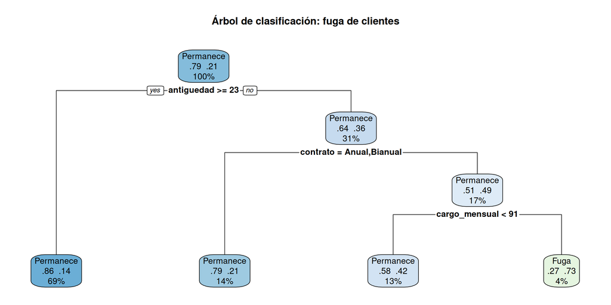

```r
arbol_fit <- decision_tree(tree_depth = 3, min_n = 150, cost_complexity = 0) |>
  set_mode("classification") |>
  fit(churn ~ ., data = entrenamiento)

rpart.plot(
  extract_fit_engine(arbol_fit),
  type = 2,
  extra = 104,
  roundint = FALSE,
  main = "Árbol de clasificación: fuga de clientes"
)
```

`extract_fit_engine()` extrae el modelo original de `rpart` para poder graficarlo con `rpart.plot()`. El árbol también puede expresarse como **reglas de decisión** para comunicarlas a la gerencia. La primera columna es la probabilidad de fuga y `cover` es el porcentaje de clientes que cumple cada regla:

**Código**

```r
rpart.rules(extract_fit_engine(arbol_fit), cover = TRUE, roundint = FALSE)
```

|  | churn |  |  |  |  |  |  |  |  |  |  |  |  | cover |
| --- | --- | --- | --- | --- | --- | --- | --- | --- | --- | --- | --- | --- | --- | --- |
| 2 | 0.14 | when | antiguedad | >= | 23 |  |  |  |  |  |  |  |  | 69% |
| 6 | 0.21 | when | antiguedad | < | 23 | & | contrato | is | Anual or Bianual |  |  |  |  | 14% |
| 14 | 0.42 | when | antiguedad | < | 23 | & | contrato | is | Mensual | & | cargo_mensual | < | 91 | 13% |
| 15 | 0.73 | when | antiguedad | < | 23 | & | contrato | is | Mensual | & | cargo_mensual | >= | 91 | 4% |

## 1.6 Random forest

Se usa el motor `randomForest` con 300 árboles. `min_n = 20` indica que cada hoja debe tener al menos 20 clientes.

**Código**

```r
set.seed(2026)
bosque_fit <- rand_forest(trees = 300, min_n = 20) |>
  set_engine("randomForest") |>
  set_mode("classification") |>
  fit(churn ~ ., data = entrenamiento)

bosque_fit
```

```
parsnip model object


Call:
 randomForest(x = maybe_data_frame(x), y = y, ntree = 300, nodesize = min_rows(~20,      x))
               Type of random forest: classification
                     Number of trees: 300
No. of variables tried at each split: 2

        OOB estimate of  error rate: 18.3%
Confusion matrix:
          Permanece Fuga class.error
Permanece      2655  115      0.0415
Fuga            525  204      0.7202
```

La importancia de las variables mide cuánto contribuye cada una a reducir la impureza (Gini) de los árboles:

**Código**

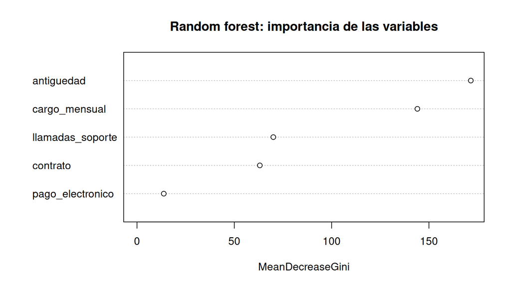

```r
randomForest::varImpPlot(
  extract_fit_engine(bosque_fit),
  main = "Random forest: importancia de las variables"
)
```

## 1.7 XGBoost

El random forest construye muchos árboles **en paralelo** e independientes, y promedia sus votos. **XGBoost** (*extreme gradient boosting*) también combina muchos árboles, pero los construye **en secuencia**: cada árbol nuevo se ajusta a los errores que dejaron los anteriores, y su aporte se suma al modelo multiplicado por una **tasa de aprendizaje** pequeña, para que el modelo avance poco a poco y no se sobreajuste.

| Hiperparámetro | Valor | Qué controla |
| --- | --- | --- |
| `trees` | 300 | Número de árboles en la secuencia |
| `tree_depth` | 3 | Profundidad de cada árbol (árboles pequeños, “débiles”) |
| `learn_rate` | 0.05 | Cuánto aporta cada árbol nuevo al modelo |
| `min_n` | 20 | Mínimo de clientes en un nodo para seguir dividiéndolo |

XGBoost solo acepta variables numéricas. Al usar la fórmula `churn ~ .`, tidymodels convierte automáticamente `contrato` en variables indicadoras (0/1).

**Código**

```r
set.seed(2026)
xgb_fit <- boost_tree(
  trees = 300,
  tree_depth = 3,
  learn_rate = 0.05,
  min_n = 20
) |>
  set_engine("xgboost") |>
  set_mode("classification") |>
  fit(churn ~ ., data = entrenamiento)

xgb_fit
```

```
parsnip model object

##### xgb.Booster
call:
  xgboost::xgb.train(params = list(eta = 0.05, max_depth = 3, gamma = 0,
    colsample_bytree = 1, colsample_bynode = 1, min_child_weight = 20,
    subsample = 1, nthread = 1, objective = "binary:logistic"),
    data = x$data, nrounds = 300, evals = x$watchlist, verbose = 0)
# of features: 7
# of rounds:  300
callbacks:
   evaluation_log
evaluation_log:
  iter training_logloss
 <num>            <num>
     1            0.504
     2            0.498
   ---              ---
   299            0.374
   300            0.374
```

La importancia de cada variable en XGBoost se mide con la **ganancia** (*gain*): cuánto mejora el ajuste, en promedio, cada vez que un árbol usa esa variable para dividir.

**Código**

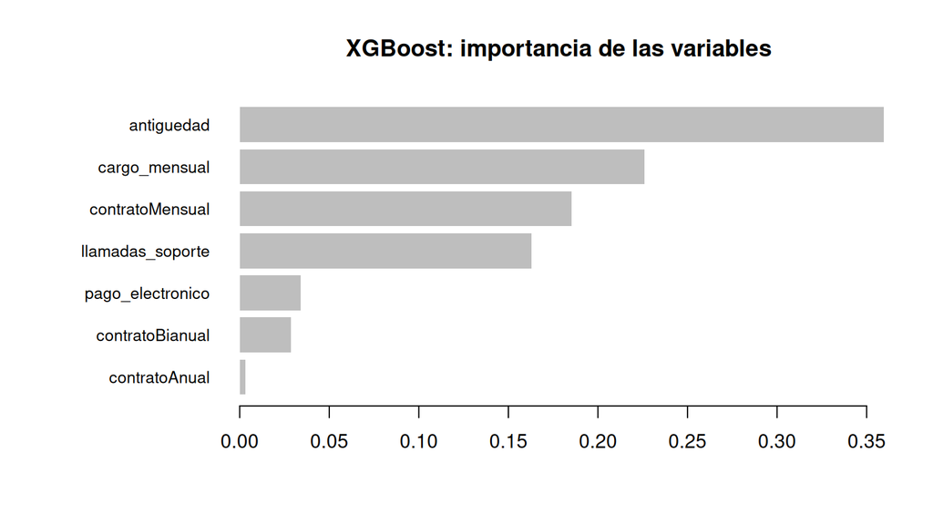

```r
importancia_xgb <- xgboost::xgb.importance(model = extract_fit_engine(xgb_fit))
xgboost::xgb.plot.importance(
  importancia_xgb,
  main = "XGBoost: importancia de las variables"
)
```

## 1.8 Comparación de modelos

`augment()` agrega a los datos de prueba las predicciones de un modelo:

- `.pred_class`: la clase predicha, con umbral 0.5.
- `.pred_Fuga`: la probabilidad de fuga.

Se juntan las predicciones de los cuatro modelos en una sola tabla; la columna `modelo` indica de qué modelo viene cada predicción.

**Código**

```r
predicciones <- bind_rows(
  "Logit" = augment(logit_fit, new_data = prueba),
  "Árbol" = augment(arbol_fit, new_data = prueba),
  "Random forest" = augment(bosque_fit, new_data = prueba),
  "XGBoost" = augment(xgb_fit, new_data = prueba),
  .id = "modelo"
)
```

Con `metric_set()` se definen las métricas que se quieren calcular. Como `Fuga` es el segundo nivel de `churn`, se indica `event_level = "second"` para que `Fuga` sea la clase positiva.

| Métrica en `yardstick` | Nombre en español |
| --- | --- |
| `accuracy` | Exactitud |
| `precision` | Precisión |
| `sensitivity` | Sensibilidad |
| `specificity` | Especificidad |
| `f_meas` | F1 |
| `roc_auc` | AUC |

**Código**

```r
mis_metricas <- metric_set(
  accuracy,
  precision,
  sensitivity,
  specificity,
  f_meas,
  roc_auc
)

predicciones |>
  group_by(modelo) |>
  mis_metricas(
    truth = churn,
    estimate = .pred_class,
    .pred_Fuga,
    event_level = "second"
  ) |>
  pivot_wider(id_cols = modelo, names_from = .metric, values_from = .estimate)
```

| modelo | accuracy | precision | sensitivity | specificity | f_meas | roc_auc |
| --- | --- | --- | --- | --- | --- | --- |
| Logit | 0.831 | 0.677 | 0.361 | 0.955 | 0.471 | 0.824 |
| Random forest | 0.834 | 0.698 | 0.361 | 0.959 | 0.476 | 0.793 |
| XGBoost | 0.842 | 0.713 | 0.406 | 0.957 | 0.517 | 0.823 |
| Árbol | 0.807 | 0.694 | 0.137 | 0.984 | 0.229 | 0.672 |

El **logit** y **XGBoost** obtienen prácticamente el mismo AUC, por encima del random forest y del árbol. Un modelo más complejo no siempre predice mejor: cuando la relación entre las variables y el *log-odds* de fuga es casi lineal, un modelo simple como el logit compite de igual a igual con XGBoost. Como además es más fácil de interpretar, en lo que sigue se trabaja con el logit. Con el umbral de 0.5 la **sensibilidad es baja** (se detecta una minoría de los clientes que se van), lo que motiva revisar el umbral.

## 1.9 Matriz de confusión y curva ROC

Matriz de confusión del logit con el umbral de 0.5:

**Código**

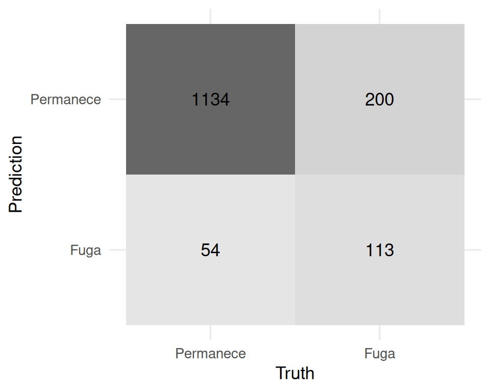

```r
pred_logit <- filter(predicciones, modelo == "Logit")

matriz <- conf_mat(pred_logit, truth = churn, estimate = .pred_class)
autoplot(matriz, type = "heatmap")
```

Curva ROC de los cuatro modelos:

**Código**

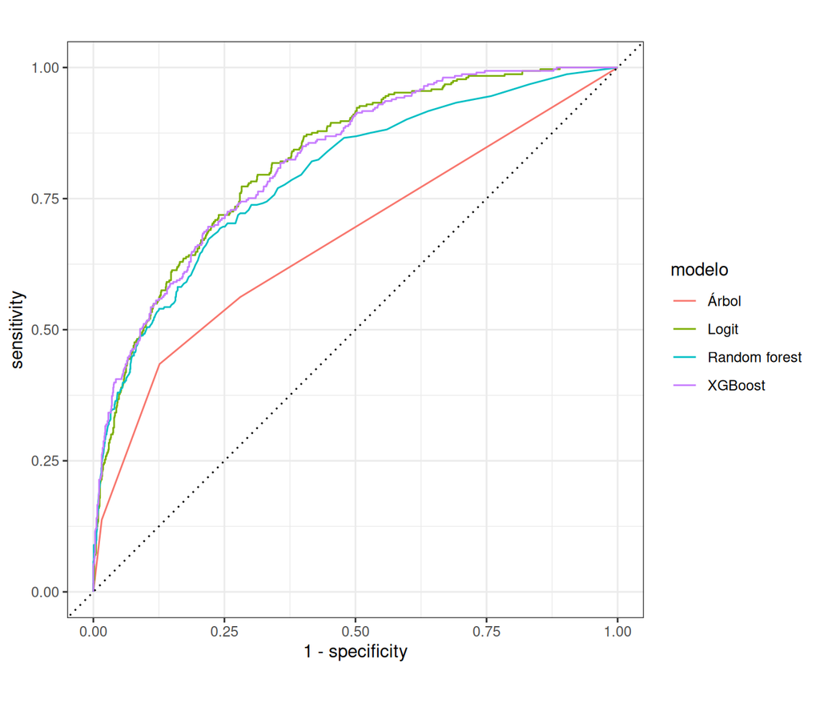

```r
predicciones |>
  group_by(modelo) |>
  roc_curve(truth = churn, .pred_Fuga, event_level = "second") |>
  autoplot()
```

## 1.10 Elegir el umbral

Los modelos anteriores predicen que un cliente se fuga cuando su probabilidad de fuga es **mayor o igual a 0.5**. Ese umbral es una convención estadística, no una decisión de negocio.

Supongamos que una campaña de retención tiene los siguentes valores:

- Contactar a un cliente cuesta **USD 20**.
- Retener a un cliente que se iba a fugar vale **USD 100**.

Si se contacta a un cliente que no se iba a ir (**falso positivo**), se pierden USD 20. Si no se contacta a un cliente que sí se iba (**falso negativo**), se pierden USD 100. Dejar escapar a un cliente cuesta **cinco veces más** que contactarlo de más.

Por eso conviene contactar también a clientes con probabilidad de fuga menor a 0.5. Por ejemplo, contactar a un cliente con probabilidad de fuga de 0.3 deja en promedio $0.3 \times 100 - 20 = 10$ USD de beneficio.

Para un umbral $u$, se contacta a todos los clientes con probabilidad de fuga mayor o igual a $u$, y el beneficio de la campaña es:

$$\text{Beneficio}(u) = 100 \cdot VP(u) - 20 \cdot \left[VP(u) + FP(u)\right]$$

donde $VP(u)$ son los clientes contactados que sí se iban a fugar y $VP(u) + FP(u)$ es el total de clientes contactados. El objetivo es encontrar el umbral que **maximiza el beneficio**.

Para cada umbral posible se calcula a cuántos clientes se contactaría y cuántos de ellos realmente se iban a fugar (verdaderos positivos):

**Código**

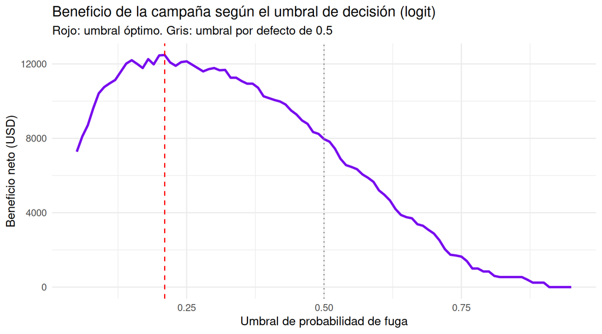

```r
umbrales <- round(seq(0.05, 0.95, by = 0.01), 2)
beneficio <- numeric(length(umbrales))

for (i in seq_along(umbrales)) {
  contactados <- pred_logit$.pred_Fuga >= umbrales[i]
  vp <- sum(contactados & pred_logit$churn == "Fuga")
  beneficio[i] <- 100 * vp - 20 * sum(contactados)
}

umbral_optimo <- umbrales[which.max(beneficio)]
beneficio_05 <- beneficio[umbrales == 0.5]

ggplot(
  tibble(umbral = umbrales, beneficio = beneficio),
  aes(umbral, beneficio)
) +
  geom_line(color = "#790cee", linewidth = 1.2) +
  geom_vline(xintercept = umbral_optimo, color = "red", linetype = "dashed") +
  geom_vline(xintercept = 0.5, color = "gray50", linetype = "dotted") +
  labs(
    title = "Beneficio de la campaña según el umbral de decisión (logit)",
    subtitle = "Rojo: umbral óptimo. Gris: umbral por defecto de 0.5",
    x = "Umbral de probabilidad de fuga",
    y = "Beneficio neto (USD)"
  )
```

Con el umbral por defecto de 0.5 la campaña genera USD 7.960. Con el umbral óptimo de 0.21 el beneficio sube a USD 12.480. Como retener a un cliente vale cinco veces lo que cuesta contactarlo, conviene contactar a muchos más clientes de los que el umbral de 0.5 sugiere.

Con el umbral óptimo, las métricas del modelo cambian: se sacrifica precisión a cambio de detectar a muchos más clientes que se van.

**Código**

```r
pred_logit <- pred_logit |>
  mutate(
    clase_optima = if_else(.pred_Fuga >= umbral_optimo, "Fuga", "Permanece"),
    clase_optima = factor(clase_optima, levels = c("Permanece", "Fuga"))
  )

metricas_clase <- metric_set(accuracy, precision, sensitivity, specificity)

bind_rows(
  "umbral 0.5" = metricas_clase(
    pred_logit,
    truth = churn,
    estimate = .pred_class,
    event_level = "second"
  ),
  "umbral óptimo" = metricas_clase(
    pred_logit,
    truth = churn,
    estimate = clase_optima,
    event_level = "second"
  ),
  .id = "umbral"
) |>
  pivot_wider(id_cols = .metric, names_from = umbral, values_from = .estimate)
```

| .metric | umbral 0.5 | umbral óptimo |
| --- | --- | --- |
| accuracy | 0.831 | 0.724 |
| precision | 0.677 | 0.413 |
| sensitivity | 0.361 | 0.773 |
| specificity | 0.955 | 0.710 |